# Modelos gráficos no dirigidos

Hasta ahora hemos restringido nuestro estudio a las redes bayesianas, otra manera usual de representar independencias condicionales y modelos asociados es a través de gráficas no dirigidas, o modelos de redes markovianas.

- Cómo se representan la independencias condicionales: en el caso Markoviano, la interpretación es más simple (caminos activos son bidireccionales no condicionados).
- Qué tipo de estructuras de independencia pueden representarse apropiadamente.
- Cómo se parametriza la conjunta: en general, en redes markovianas no es posible utilizar modelos locales de probabilidades condicionales como en los modelos dirigidos.

### Propiedad markoviana por pares

Consideramos variables aleatorias discretas $X_1, \ldots, X_k$ con una función de distribución conjunta $p(x_1,\ldots, x_k)$. Supondremos, para simplificar la discusión, que $p(x_1,x_2,\ldots, x_k)>0$ para cualquier combinación de $x_1,\ldots, x_k$.

Un primer enfoque es construir una gráfica $\mathcal M$ no dirigida de la siguiente forma:

Decimos que ${\mathcal M}$ tiene la **propiedad Markoviana por pares** respecto a la distribución $p$ cuando es una red no dirigida con vértices $X_1, \ldots, X_k$ tal que: $\mathcal M$ no tiene arista entre $X_i$ y $X_j$ si y sólo si $X_i$ y $X_j$ son independendientes dado el resto de variables aleatorias.

Es decir, existe un arco solamente cuando existe una relación directa entre las dos variables no mediada por dependencia entre otras variables.

**Ejemplos.**  
Consideremos tres variables aleatorias: $X,Y,Z$. Hay tres posibles independencias condicionales por pares a considerar: $X\bot Y|Z$, $X\bot Z|Y$ y $Y\bot Z|Y$. Si ninguna se cumple, la gráfica es completa:

```r
library(gRbase)
library(Rgraphviz)
library(igraph)
library(gRim)

miPlot <- function(x, ...){
  V(x)$size <- 55
  V(x)$label.cex <- 1.5
  V(x)$color <- "salmon"
  # plot(x, ...)
}

ug_ej1 <- ug(c("X", "Y"), c("Y", "Z"), c("X", "Z"), result = "igraph")
miPlot(ug_ej1)
```

Si se cumple solamente $X\bot Y|Z$, entonces tenemos

```r
ug_ej2 <- ug(c("Y", "Z"), c("X","Z"), result = "igraph")
miPlot(ug_ej2)
```

Si se cumplen solamente $X\bot Y|Z$ y $X\bot Z|Y$

```r
ug_ej3 <- ug(~ Y:Z, ~ X, result = "igraph")
miPlot(ug_ej3)
```

### Propiedad markoviana global

¿Qué otras propiedades de independencia condicional se pueden leer de esta gráfica? La regla es más fácil que la de redes dirigidas, donde teníamos que tener cuidado con caminos activados por un colisionador. En redes no dirigidas, el concepto de separación es directo:

Sea $C$ un conjunto de vértices de una red $\mathcal M$. Decimos que dos vértices $X$ y $Y$ están **separados por $C$** en $\mathcal M$ si todos los caminos no dirigidos entre $X$ y $Y$ pasan por algún vértice de $C$.

Decimos que $\mathcal M$ satisface la **propiedad markoviana global** respecto a $p$ cuando:  
Si $A,B,C$ son subconjuntos disjuntos de los vértices tal que $C$ separa a $A$ de $B$, entonces $A\bot B|C$.

**Ejemplo.** Consideramos la siguiente gráfica que satiface la propiedad markoviana global para $p$:

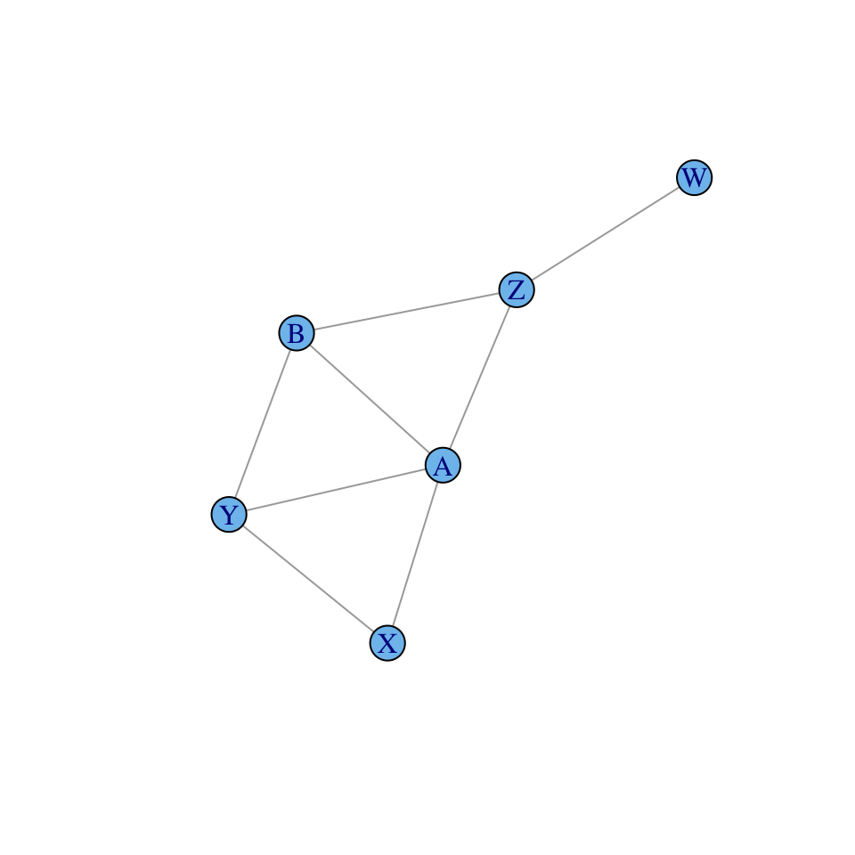

```r
ug_ej4 <- ug( c("X", "Y"), c("X","A"), c('Y','A'), c('A','B'), c('Y','B'),
  c('A','Z'), c('Z','W'), c('B','Z'), result = "igraph")
plot(ug_ej4)
```

Podemos leer, por ejemplo, las independencias $X\bot Z|A,B$, o $Y\bot W|Z$.

Para distribuciones positivas, tenemos que la propiedad global markoviana es equivalente a la propiedad markoviana por pares.

Esto implica:  
* Para una distribución $p$, podemos construir su red Markoviana asociada usando la propiedad markoviana por pares.  
* Para leer qué otras independencias satisface $p$, podemos usar la propiedad markoviana global.

### Factores y parametrización de redes markovianas

En redes dirigidas vimos que podíamos parametrizar una red bayesiana a través de factores obtenidos de modelos locales de probabilidades condicionales. El caso no dirigido, como veremos, requiere otro tipo de parametrización con base en factores.

Consideremos la red no dirigida $X\text{--}Z\text{--}Y$. ¿Cómo podemos representar su conjunta (que satisface la independencia de X y Y dado Z y ninguna otra)?

Recordemos que este conjunto de independencias se puede representar de varias maneras con redes dirigidas. Tenemos

$X\rightarrow Z \rightarrow Y: p(x)p(z|x)p(y|z)$ $X\leftarrow Z \leftarrow Y: p(y)p(z|y)p(x|z)$ $X\leftarrow Z \rightarrow Y: p(z)p(x|z)p(y|z)$

Pero no podemos representarla mediante un colisionador

$X\rightarrow Z \leftarrow Y: p(x)p(y)p(z|x,y).$

¿Qué tienen en común las factorizaciones que representan $X\text{--}Z\text{--}Y$ que es diferente del cuarto caso? En cada uno de los primeros tres casos, podemos factorizar $p(x,y,z)=\psi_1 (x,z)\psi_2(y,z),$ mientras que no es posible hacer esta factorización en el cuarto caso. Por otra parte, recordamos ahora que precisamente la ecuación anterior es equivalente a independencia condicional de $X$ y $Y$ dado $Z$.

En realidad, para que la independencia condicional se cumpla no es necesario tener igualdad en la ecuación de arriba. Basta que $p(x,y,z)\propto \psi_1 (x,z)\psi_2(y,z),$ donde los factores $\psi_1$ y $\psi_2$ sólo tienen que ser funciones no negativas.

**Ejemplo.** Consideramos la red no dirigida

```r
ug_ej5 <- ug(c("X","Y"), c("X", "W"), c("W", "Z"), c("Z","Y"), result = "igraph")
miPlot(ug_ej5)
```

Sabemos que el conjunto de independencias condicionales que satisface esta red no se pueden representar de manera perfecta mediante una red bayesiana. La razón es que cualquier direccionamiento de sus arcos tiene que producir un colisionador, y si hay un colisionador entonces tenemos dependencias que se activan al condicionar.

Usando la idea del ejemplo anterior, podríamos escribir

$p(x,y,z,w)\propto \psi_1(x,y)\psi_2(y,z)\psi_3(z,w)\psi_4(w,x)$

donde las funciones $\psi_i$ son no negativas, sin embargo, el lado derecho no tiene que sumar uno. Normalizando se sigue que $p(x,y,z,w)=\frac{\psi_1(x,y)\psi_2(y,z)\psi_3(z,w)\psi_4(w,x)}{Z}$ donde $Z=\sum_{x,y,z,w} \psi_1(x,y)\psi_2(y,z)\psi_3(z,w)\psi_4(w,x)$ es la constante que normaliza el producto de los factores.

Bajo una distribución que se factoriza de esta manera, ¿será cierto que $X\bot Z|Y,W$? Un cálculo simple muestra que así es. Tenemos que $p(x|y,z,w)=\frac{p(x,y,z,w)}{p(y,z,w)}$ La constante de normalización se cancela, así que $p(x|y,z,w)= \frac{\psi_1(x,y)\psi_2(y,z)\psi_3(z,w)\psi_4(w,x)}{\psi_2(y,z)\psi_3(z,w)\sum_x \psi_1(x,y)\psi_4(w,x)}$ entonces $p(x|y,z,w)= \frac{\psi_1(x,y)\psi_4(w,x)}{\sum_x \psi_1(x,y)\psi_4(w,x)}.$ Esta cantidad no depende de $z$, por lo que tenemos $p(x|y,z,w)=p(x|y,w),$ es decir $X\bot Z|Y,W$.

Un argumento similar puede darse para $Y\bot W | X,Z$.  
¿La factorización implica alguna otra independencia condicional? Dando contraejemplos de distribuciones particulares podemos mostrar que no, para entender la razón veamos un ejemplo: ¿$Y\bot W |X$?. Usando la factorización,

$p(y|w,x)=\frac{\psi_1(x,y)\sum_z\psi_2(y,z)\psi_3(z,w)} {\sum_y \psi_1(x,y) \left(\sum_z \psi_2(y,z)\psi_3(z,w) \right)},$ donde vemos que en el lado derecho no podemos eliminar la dependencia de $w$.

Finalmente, bajo este criterio, una red como

```r
ug_ej6 <- ug(c("X","Y"), c("Y", "Z"), c("Z","X"), result = "igraph")
miPlot(ug_ej6)
```

tiene la factorización vacía $p(x,y,z)\propto \psi(x,y,z),$ pues cualquier otra factorización implicaría independencias condicionales.

Nótese en general que una gráfica completa (donde hay un arco entre cualquier par de vértices) no puede factorizarse de manera no trivial, pues otra vez, esto implicaría independencias condicionales adicionales.

Definimos entonces una **subgráfica completa maximal** (o cliques) $\mathcal C$ de $\mathcal M$ cuando es una subgráfica completa a la que no se le puede agregar ningún nodo adicional y que siga siendo completa. Por ejemplo, en la gráfica

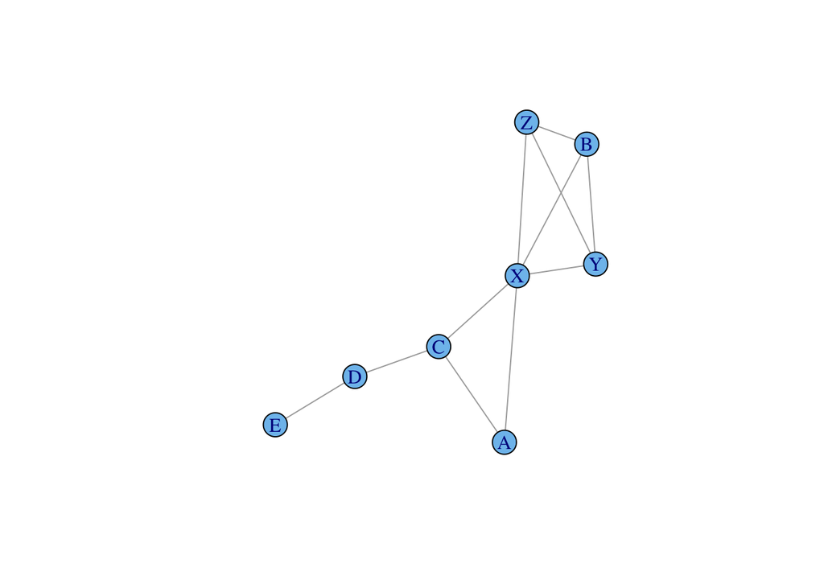

```r
ug_ej7 <- ug(c("X", "Y"), c("Y", "Z"), c("Z", "X"), c('A', 'X'), c('B', 'Y'),
             c('B', 'Z'), c('B', 'X'), c('A', 'C'), c('X', 'C'), c('C', 'D'),
             c('D', 'E'), result = "igraph")
plot(ug_ej7)
```

las subgráficas completas maximales son $\{X,Y,Z,B\}$, $\{ X,A,C\}$, $\{ C,D\}$ y $\{ D,E\}$. Basta especificar los nodos pues todas ellas son completas.

**Distribuciones de Gibbs.** Decimos que $p$ es una distribución de Gibbs respecto a ${\mathcal M}$ si se puede escribir como $p(x)\propto \prod_{c\in {\mathcal C}} \psi_c (x_c),$ donde ${\mathcal C}$ es el conjunto de cliques de $\mathcal M$, y cada $\psi_c$ es un factor (no negativo) que sólo depende de las variables dentro del clique $c$.

La siguiente figura ejemplifica los de factores sobre cliques.

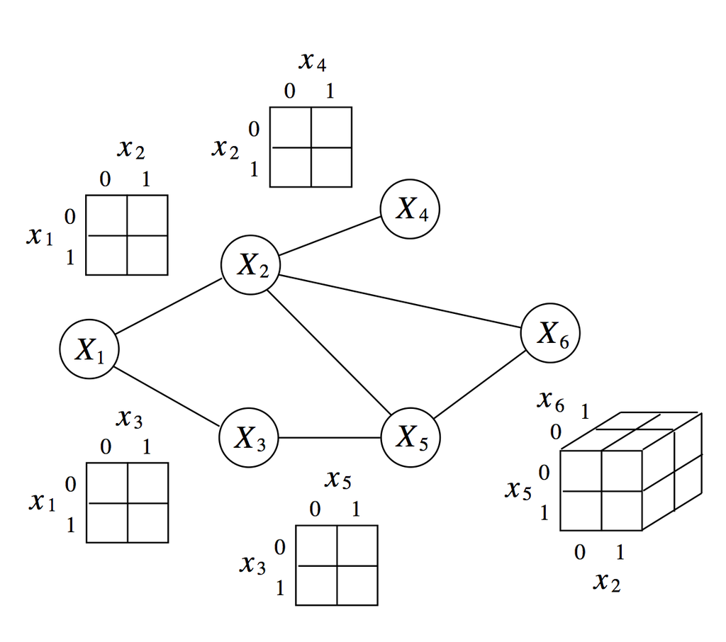

Obsérvese que de la factorización anterior recuperamos la conjunta normalizando: $p(x)=\frac{ \prod_{c\in {\mathcal C}} \psi_c (x_c)}{Z},$ donde $Z$ es el factor de normalización (también llamada función de partición) $Z=\sum_{x}\prod_{c\in {\mathcal C}} \psi_c (x_c).$

En las definiciones anteriores hemos escrito el producto de factores:

Sean $X$, $Y$ y $Z$ tres conjuntos disjuntos de variables (esto es, conjuntos con intersección vacía), y sean $\phi_1(X,Y)$ y $\phi_2(Y,Z)$ dos factores. Definimos el producto de factores $\phi_1 \times \phi_2$ como el factor $\psi:Val(X,Y,Z)\rightarrow \mathbb{R}$: $\psi(X,Y,Z) = \phi_1(X,Y)\cdot \phi_2(Y,Z)$

Notemos que tanto las densidades de probabilidad condicional como las distribuciones conjuntas son factores, por ejemplo cuando calculamos la probabilidad conjunta $p(A,B) = p(A)p(B|A)$ estamos realizando un producto de factores. En redes bayesianas también podemos ver la multiplicación de factores, si definimos $\phi_{X_i}(X_i,Pa_{X_i}) = p(X_i|Pa_{X_i})$ tenemos $p(X_1,...,X_n) = \prod_i \phi_{X_i}.$

**Ejemplo.** Una distribución $p$ es **Gibbs respecto a la gráfica** anterior cuando podemos factorizar $p(x)\propto \psi_1 (x,y,z,b)\psi_2(x,a,c)\psi_3(c,d)\psi_4(d,e)$

Esta factorización implica, como hemos visto, ciertas relaciones de independencia condicional. Por ejemplo, podemos demostrar que $Y$ y $D$ son condicionalmente independientes dada $X$:

$p(y,d,x)=\left( \sum_e\psi_4(d,e) \right) \left( \sum_{a,c}\psi_3(c,d)\psi_2(x,a,c) \right) \left( \sum_{z,b}\psi_1(x,y,z,b) \right)$ y vemos que en el cociente con $p(d,x)$, se eliminan los factores $\left( \sum_e\psi_4(d,e) \right) \left( \sum_{a,c}\psi_3(c,d)\psi_2(x,a,c) \right)$. El término restante no depende de $d$. }

Ahora vemos que la factorización es precisamente la expresión que necesitamos para expresar las independencias condicionales que se leen de la gráfica:

**Hammersley-Clifford**. Sea $p$ una distribución positiva. Entonces $p$ es Gibbs en relación a $\mathcal M$ si y sólo si $\mathcal M$ satisface la propiedad global de Markov respecto a $p$.

Entonces, de manera similar a gráficas dirigidas vimos dos maneras de caracterizar los modelos gráficos no dirigidos:

1. Dada una gráfica $\mathcal M$, todas las distribuciones que se pueden expresar como el producto de factores (o potenciales) definidos sobre cliques (subgráficas completas maximales).
2. Dada una gráfica $\mathcal M$, todas las distribuciones que satisfacen todas las independencias que especifica la gráfica.
3. Hammersley-Clifford: Las dos caracterizaciones son equivalentes.

Para la siguiente gráfica ¿Que afirmaciones de independencia están en I($\mathcal{M}$), es decir que independencias están inducidas por la gráfica?

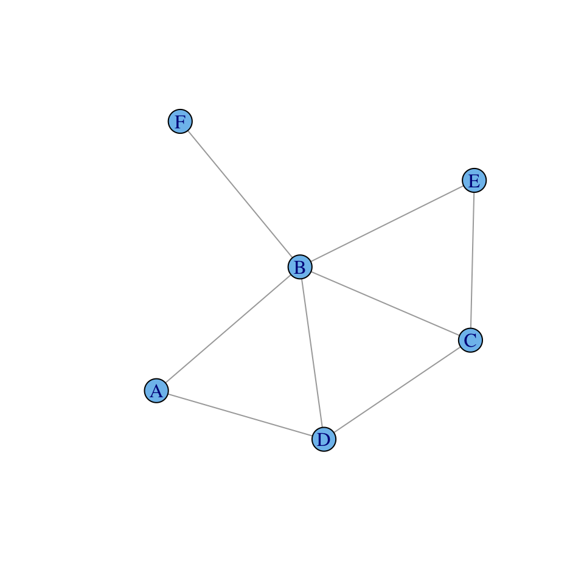

1. ($A \bot C| B,D$)
2. ($A\bot E| B$)
3. ($C\bot F|B$)
4. ($A \bot F|B,D$)
5. Ninguna.

### Factores y parametrización

```r
ug_ej7 <- ug(c("A","D"), c("A", "B"), c("B","C"), c("C", "D"), result = "igraph")
miPlot(ug_ej7)
```

Describimos la relación entre Ana y Benito mediante un factor $\phi_1(A,B):Val(A,B)\rightarrow \mathbb{R}^+$, donde el valor de cada asignación $(a,b)$ corresponde a la $afinidad$ entre los dos valores, un mayor valor $\phi_1(a,b)$ indica mayor compatibilidad entre $a$ y $b$.

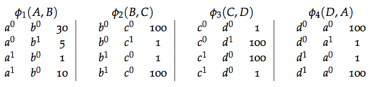

¿Por qué $\phi_1(a,b)\cdot \phi_2(b,c) \cdot \phi_3(c,d)\cdot\phi_4(d,a)$ no es una distribución de probabilidad?  
a. Puede ser negativo.  
b. No necesariamente está entre 0 y 1.  
c. No suma uno ($\sum_{a b c d}\phi_1(a,b)\cdot \phi_2(b,c) \cdot \phi_3(c,d)\cdot\phi_4(d,a)$).  
d. Faltan factores para determinar la distribución (ej. $\phi_1(a,c)$)

De manera similar a las redes bayesianas, debemos combinar los modelos locales para definir el modelo global; sin embargo, la multiplicación de los factores no tiene porque definir una distribución por lo que es necesario normalizar el producto de factores.

En el ejemplo de los estudiantes definimos: $p(a,b,c,d) = \frac{1}{Z}\phi_1(a,b)\cdot \phi_2(b,c) \cdot \phi_3(c,d)\cdot\phi_4(d,a)$ donde $Z = \sum_{a,b,c,d} \phi_1(a,b)\cdot \phi_2(b,c) \cdot \phi_3(c,d) \cdot \phi_4(d,a)$ es la constante de normalización que también se conoce como función de partición.

Calculamos la distribución de probabilidad conjunta multiplicando los factores y normalizando como sigue: $p(a,b,c,d) = \frac{1}{Z}\phi_1(a,b)\cdot \phi_2(b,c) \cdot \phi_3(c,d)\cdot\phi_4(d,a)$ donde $Z = \sum_{a,b,c,d} \phi_1(a,b)\cdot \phi_2(b,c) \cdot \phi_3(c,d) \cdot \phi_4(d,a)$ es la constante de normalización.

Obtenemos así la siguiente tabla que describe la distribución conjunta de las variables aleatorias:

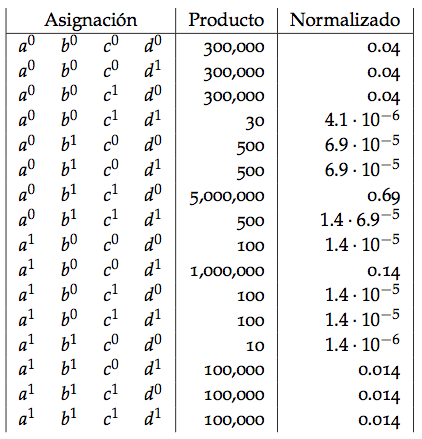

#### Parametrización

Para representar una distribución necesitamos asociar la estructura de la gráfica con un conjunto de parámetros de manera similar a como las funciones de densidad condicional parametrizan las gráficas dirigidas. Sin embargo, la parametrización de redes markovianas no es tan intuitiva ya que los factores no corresponden a probabilidades, esto conlleva a que los parámetros sean difíciles de entender y por tanto no es fácil elicitarlos de expertos. Para entender que la relación entre los factores y la distribución de probabilidad no se relacioan de manera intutiva comparemos el factor $\phi_1(A,B)$ con la distribución marginal $p_\Phi(A,B)$:

Si consideramos el factor $\phi_1(A,B)$, nos preguntamos si dicho factor es es proporcional a:  
a. La probabilidad marginal $p(A,B)$.  
b. La probabilidad condicional $p(A|B)$.  
c. La probabilidad condicional $p(A,B|C,D)$.  
d. Ninguna de las anteriores

Para entender que la relación entre los factores y la distribución de probabilidad no es intutiva comparemos el factor $\phi_1(A,B)$ con la distribución marginal $p_\Phi(A,B)$:

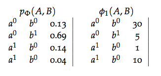

## Representación log-lineal

Los modelos log-lineales han sido ampliamente utilizados en ciencias sociales para el análisis de tablas de contingencia, su desarrollo ha permitido formular y ajustar patrones de asociación complejas entre los dactores que cruzan en una tabla de contingencias.

**Ejemplo**. Usaremos la base de datos de lagartijas, tenemos $N=409$ observaciones y $d=3$ variables.

```r
library(gRbase)
library(gRim)

data(lizard)
```

Un modelo log-lineal permite expresar el log de las probabilidades con expresiones de factoriales. Por ejemplo, para un modelo de *saturado* (donde se estiman parámetros para todos los cruces de factores) de 3 variables tenemos:

$\log p(x) = u + u_X + u_Y + u_Z + u_{X,Y} + u_{X,Z} + u_{Y,Z} + u_{X,Y,Z}$

donde las $u$ son parámetros desconocidos.

En el ejemplo de lagartijas, si no restringimos las probabilidades del modelo (es decir, estimamos todos los cruces), tenemos un total de 8 parámetros (7 pues el último está dado), para cada parámetro la estimación de máxima verosimilitud es $p_i=n_i/N$, esto es la proporción de observaciones en la celda i.

```r
prop.table(lizard)
```

```
## , , species = anoli
##
##      height
## diam  >4.75 <=4.75
##   <=4 0.078  0.210
##   >4  0.027  0.086
##
## , , species = dist
##
##      height
## diam  >4.75 <=4.75
##   <=4 0.149  0.178
##   >4  0.100  0.171
```

Repetimos la estimación utilizando la representación log-lineal:

```r
data(lizardRAW) # datos desagregados
m_sat <- dmod(~.^., data = lizardRAW)
m_sat$fit$fit
```

```
## , , species = anoli
##
##      height
## diam  <=4.75 >4.75
##   <=4     86    32
##   >4      35    11
##
## , , species = dist
##
##      height
## diam  <=4.75 >4.75
##   <=4     73    61
##   >4      70    41
```

Los modelos log-lineales nos permiten hacer cero algunas interacciones, por ejemplo podemos ajustar:

$\log p(x) = u + u_X + u_Y + u_Z + u_{X,Y} + u_{X,Z}$

```r
m_2 <- dmod(~species*height+species*diam, data = lizard)
m_2$fit$fit
```

```
## , , species = anoli
##
##      height
## diam  >4.75 <=4.75
##   <=4    31     87
##   >4     12     34
##
## , , species = dist
##
##      height
## diam  >4.75 <=4.75
##   <=4    56     78
##   >4     46     65
```

En las siguientes secciones estudiaremos la relación entre una clase de modelos log-lineales y redes markovianas.

### Modelos gráficos log-lineales

Recordemos que algunos de los resultados de redes markovianas se sostenían únicamente para conjuntas positivas, por lo que podemos restringirnos a este conjunto y por tanto podemos representarlas de manera lgoarítmica de la siguiente forma:

Una distribución de Gibbs sobre $\mathcal M$ se escribe

$p(x) \propto \prod_{c\in {\mathcal C}} \psi_c (x_c).$

Si todos los factores son positivos $\psi_c>0$, definimos $u_c=\log (\psi_c)$ de manera que

$p(x)\propto \prod_{c\in {\mathcal C}} \exp (u_c (x_c)).$ y $p(x)= \frac{\prod_{c\in {\mathcal C}} \exp (u_c (x_c))}{Z},$ donde $Z= \sum_{x} \exp \left( \sum_{c\in {\mathcal C}}^{} {u_c(x_c)} \right).$

Podemos también escribir

$\log (p(x)) = \sum_{c\in {\mathcal C}}^{} u_c(x_c) - \log Z$

donde $\log Z$ es una constante de normalización.

La última expresión corresponde a un modelo log-lineal. En el resto de esta discusión, consideraremos la expresión log lineal para la conjunta, y supongamos que tenemos tres variables binarias que toman los valores $0,1$. Comenzamos con el modelo deindependencia (o solamente de efectos principales), que es

$\log p(x) = u + u_X + u_Y + u_Z$

donde $u$ representa el término de normalización. Esta gráfica corresponde a la gráfica de $X,Y,Z$ sin arcos. Nótese que esta expresión está sobreparametrizada (contiene 6 parámetros, pero la conjunta solo depende de 3 parámetros). Esto quiere decir que hay una infinidad de maneras de representar a una misma conjunta por medio de las $u$. Este punto no es crucial, pero podríamos restringir a $u_X(0)=u_Y(0)=u_Z(0)=0$ y así obtenemos otra vez 3 parámetros.

Ahora supongamos que queremos eliminar la independencia entre $X$ y $Z$. En lugar de reescribir la expresión (absorbiendo $u_X$ y $u_Z$ en un factor $u_{X,Z}$), agregamos un término a la expresión anterior:

$\log p(x) = u + u_X + u_Y + u_Z + u_{X,Z}$

Ahora agregemos una nueva arista entre $Z$ y $Y$. Podemos escribir

$\log p(x) = u + u_X + u_Y + u_Z + u_{X,Z} + u_{Y,Z}$

que con la misma restricción $u_{Y,Z}(y,z)=0$ cuando $y=0$ o $z=0$ resulta en 5 parámetros, que es el número correcto (pues la conjunta se puede parametrizar con 1 parámetro para la marginal de $Z$, y la condicional de $(X,Y)$ dado $Z$ solo requiere 4 parámetros en lugar de 6 debido a la independencia $X\bot Y|Z$).

Finalmente, ¿qué sucede cuando agregamos el arco entre $X$ y $Y$?

$\log p(x) = u + u_X + u_Y + u_Z + u_{X,Z} + u_{Y,Z} + u_{X,Y}+u_{X,Y,Z}.$

Tenemos que agregar el último término para poder capturar todos los patrones de dependencia de la gráfica completa de $X$, $Y$,$Z$, pues esta gráfica contiene un factor $\psi(x,y,z)$. Nótese que si no agregamos este término $u_{X,Y,Z}$, entonces terminaríamos con 6 parámetros, pero sabemos que para parametrizar cualquier conjunta requerimos 8-1=7 parámetros.

Así que el modelo $\log p(x) = u + u_X + u_Y + u_Z + u_{X,Z} + u_{Y,Z} + u_{X,Y}$

tiene restricciones adicionales a las del modelo con gráfica completa, pues $u_{X,Y,Z}=0$. Este modelo es un modelo log-lineal (en la definición usual), pero no es un modelo log-lineal *gráfico*, pues expresa independencias que no se pueden leer de la gráfica.

A los términos $u$ se les llama muchas veces **términos de interacción**.

Siguiendo el proceso de construcción de arriba el tipo de modelos que nos interesa es:

Un modelo log-lineal gráfico asociado a la gráfica $\mathcal M$ es de la forma $\log p(x) = u + \sum_i \phi_i^1 u_i + \sum_{i,j}\phi_{i,j}^2 u_{i,j}+\cdots + \sum_{i_1,\ldots, i_s} \phi_{i_1,\ldots, i_s}^s u_{i_1,\ldots, i_s}$ donde

1. Las $\phi$ toman el valor 1 o 0.
2. El modelo es jerárquico: si un término $\phi_{i_1,\ldots, i_t}=1$, entonces todos los términos $\phi_A=1$ para todo $A\subset {i_1,\ldots, i_t}$.
3. Los términos más altos de la expresión coresponden a cliques en $\mathcal M$.

**Ejemplos**

- La expresión $u+ u_X+ u_{YZ}$ no es jerárquica. No puede resultar de la construcción que hicimos arriba, y por lo tanto tampoco puede ser un modelo gráfico.
- La expresión $u+ u_X+ u_Y+u_Z + u_{XY} + u_{XYZ}$ no es jerárquica. No puede resultar de la construcción que hicimos arriba, y por lo tanto tampoco puede ser un modelo gráfico.

*La expresión $u + u_X + u_Y + u_Z + u_{X,Z} + u_{Y,Z} + u_{X,Y}$ es un modelo jerárquico, pero no es gráfico, pues $X,Y,Z$ forman un clique, así que el término $u_{X,Y,Z}$ no puede restringirse a ser 0.

Considera $u+u_1+u_2+u_3+u_4+u_5+u_{12}+u_{23}+u_{25}+u_{35}+u_{34}+u_{45}$

1. Es un modelo gráfico
2. Es un modelo jerárquico
3. Ninguna de las anteriores

**Observación:** En primer lugar, nótese que sin la parametrización y las restricciones que mostramos arriba, no tienen mucho sentido preguntarse si un modelo es jerárquico, pues todos los términos de grado más bajo se pueden absorber en el de orden más alto. La pregunta sería entonces: ¿por qué no usar con esta parametrización modelos no jerárquicos? Podemos por ejemplo considerar el modelo ($X$ y $Y$ binarias): $u+u_X+u_{X,Y}$ con la restricción de que $u_X(0)=0$ y $u_{X,Y}(0,y)=u_{X,Y}(x,0)=0$. Entonces nótese que se tiene que cumplir que $p(0,0)=p(0,1)$. Es decir, bajo esta parametrización modelos no jerárquicos *incluyen otras restricciones que no tienen qué ver con la independencia condicional*. No es que estos modelos no sirvan o estén mal, sino que en este punto no nos interesa modelar ese tipo de restricciones. En la práctica, típicamente se usan modelos jerárquicos.

### Ajuste de modelos loglineales

Igual que en la gráficas no dirigidas, podemos escribir de manera fácil la verosimilitud bajo ciertos valores de los factores $u$ de datos observados:

$loglik(\theta, {\mathcal L})=\sum_i \log p(\theta; x^{(i)}),$ donde $log(p(\theta; x^{(i)})$ es la probabilidad de la observación $x^{(i)}$ según el modelo dado por la factorización, y $\theta$ incluye todos los parámetros de los factores.

La diferencia más importante es que en general, no podemos usar la descomposición que hicimos en redes bayesianas de la verosimilitud.

En redes bayesianas, podíamos descomponer la verosimilitud en factores que correspondían a modelos locales, y resolver por separado para cada modelo local. En redes markovianas esto no es posible por la presencia del factor de normalización (en el que intervienen todos los parámetros de los factores en el modelo).

Tomando en cuenta esta diferencia hay varias maneras de estimar una red markoviana, uno de los métdos consiste en realizar pruebas de independencia para inferir la estructura del modelo conjunto. Y otro en utilizar heurísticas para optimizar un criterio.

Recordemos que en general no seleccionamos modelos usando la log-verosimilitud, sino que usaremos el AIC para seleccionar modelos que exploramos mediante una heurística más simple: dada una gráfica inicial no dirigida, en cada paso buscamos la eliminación o agregación del arco que resulte en la mejor ganancia en AIC.

Comenzaremos por ejemplo del *error en clase*. Primero simulamos datos según los datos del ejemplo, con una variable de ruido adicional:

```r
library(dplyr)
potencial <- expand.grid(d = c(0, 1), c = c(0, 1), b = c(0, 1), a = c(0, 1)) %>%
  mutate(
    valor = c(3e05, 3e5, 3e5, 30, 500, 500, 5e6, 500, 100, 1e6, 100, 100, 10,
      1e5, 1e5, 1e5),
    indice = 1:n(),
    prob = valor/sum(valor)
    )
set.seed(2805)
muestra <- sample_n(potencial, size = 3000, weight = prob, replace = T) %>%
  select(d, c, b, a)
# añadimos una variable independiente
muestra$e <- sample(c(0, 1), 3000, replace=T)
```

La función *dmod* sirve para especificar modelos log-lineales.

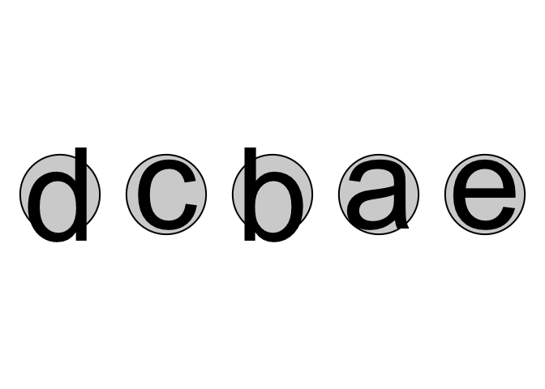

```r
library(gRim)

m_init <- dmod(~.^1, data = muestra) # modelo de independencia
plot(m_init)
```

Para usar el AIC o BIC, ponemos manualmente el coeficiente de penalización (2 para AIC y $\log N$ para BIC):

```r
mod_misco <- stepwise(m_init, k = log(nrow(muestra)),
  direction='forward', type='unrestricted')
mod_misco
```

```
## Model: A dModel with 5 variables
##  graphical :  TRUE  decomposable : FALSE
##  -2logL    :       10602.20 mdim :    9 aic :     10620.20
##  ideviance :        6050.51 idf  :    4 bic :     10674.26
##  deviance  :          12.68 df   :   22
## Notice: Table is sparse
##   Asymptotic chi2 distribution may be questionable.
```

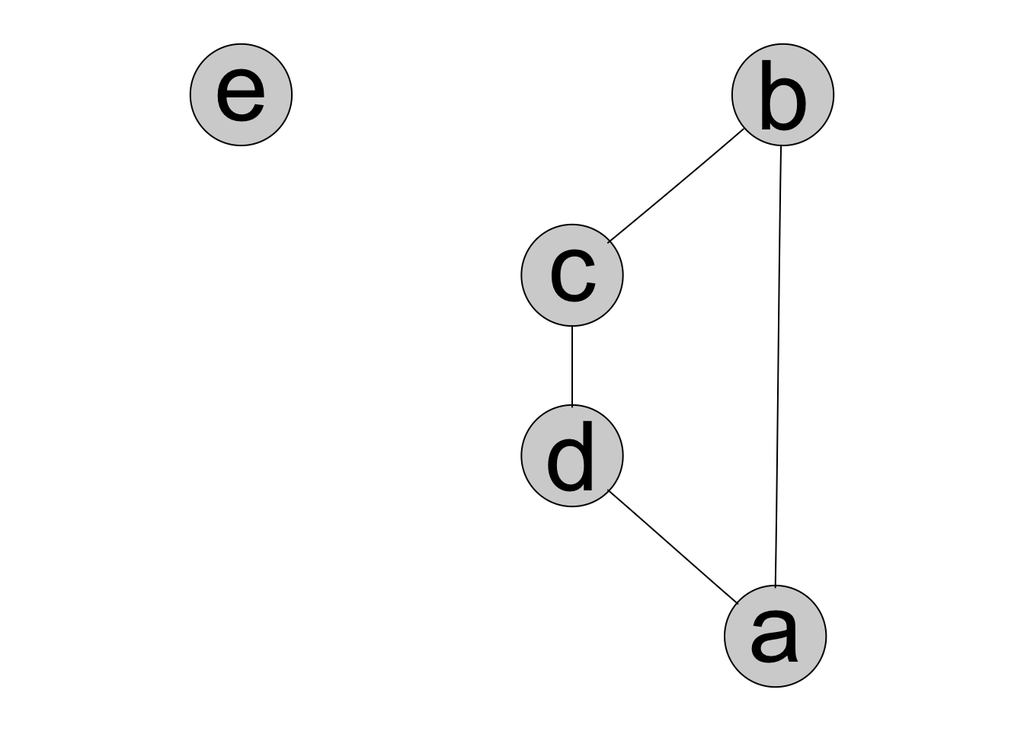

```r
plot(mod_misco)
```

Las probabilidades ajustadas son (se puede omitir del cálculo en *stepwise* cuando es una tabla muy grande):

```r
library(ggplot2)

ajuste <- mod_misco$fit$fit
ajuste
```

```
## , , b = 0, a = 0, e = 0
##
##    c
## d         0       1
##   0 5.6e+01 5.8e+01
##   1 5.8e+01 3.7e-02
##
## , , b = 1, a = 0, e = 0
##
##    c
## d         0       1
##   0 4.4e-01 1.0e+03
##   1 4.5e-01 6.5e-01
##
## , , b = 0, a = 1, e = 0
##
##    c
## d         0       1
##   0 1.0e-01 1.1e-01
##   1 2.0e+02 1.3e-01
##
## , , b = 1, a = 1, e = 0
##
##    c
## d         0       1
##   0 7.8e-03 1.8e+01
##   1 1.5e+01 2.1e+01
##
## , , b = 0, a = 0, e = 1
##
##    c
## d         0       1
##   0 6.0e+01 6.2e+01
##   1 6.2e+01 4.0e-02
##
## , , b = 1, a = 0, e = 1
##
##    c
## d         0       1
##   0 4.7e-01 1.1e+03
##   1 4.9e-01 7.0e-01
##
## , , b = 0, a = 1, e = 1
##
##    c
## d         0       1
##   0 1.1e-01 1.2e-01
##   1 2.2e+02 1.4e-01
##
## , , b = 1, a = 1, e = 1
##
##    c
## d         0       1
##   0 8.4e-03 1.9e+01
##   1 1.6e+01 2.3e+01
```

```r
ajuste_df <- data.frame(ajuste) %>%
  group_by(a, b, c, d) %>%
  summarise(freq = sum(Freq)) %>%
  ungroup() %>%
  mutate(prob_aj = freq / sum(freq)) %>% # probabilidad ajustada
  mutate_each(funs(as.numeric(as.character(.))), a:d)

# comparamos con las probabilidades originales
ej_comp <- inner_join(ajuste_df, potencial)
```

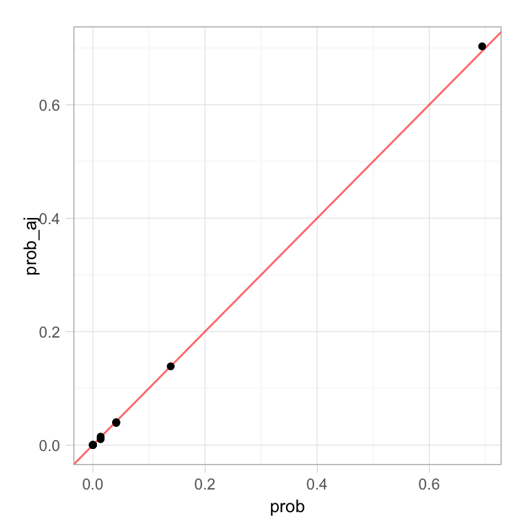

```r
ggplot(ej_comp, aes(x = prob, y= prob_aj)) +
  geom_abline(color = "red", alpha = 0.6) +
  geom_point()
```

En el siguiente ejemplo, seleccionamos un modelo para datos de riesgo de enfermedades del corazón. Tenemos 6 variables: fuma o no, si hace trabajo mental, si hace trabajo físico, si tiene presión baja, un indicador de colesterol alto, y un indicador de historia familiar de enfermedad del corazón:

```r
library(gRim)
data(reinis)
reinis
```

```
## , , phys = y, systol = y, protein = y, family = y
##
##      mental
## smoke   y   n
##     y  44 112
##     n  40  67
##
## , , phys = n, systol = y, protein = y, family = y
##
##      mental
## smoke   y   n
##     y 129  12
##     n 145  23
##
## , , phys = y, systol = n, protein = y, family = y
##
##      mental
## smoke   y   n
##     y  35  80
##     n  12  33
##
## , , phys = n, systol = n, protein = y, family = y
##
##      mental
## smoke   y   n
##     y 109   7
##     n  67   9
##
## , , phys = y, systol = y, protein = n, family = y
##
##      mental
## smoke   y   n
##     y  23  70
##     n  32  66
##
## , , phys = n, systol = y, protein = n, family = y
##
##      mental
## smoke   y   n
##     y  50   7
```

[output cut: 56 more lines]

```
##     n  16   3
##
## , , phys = y, systol = n, protein = n, family = n
##
##      mental
## smoke   y   n
##     y   4  13
##     n   0  11
##
## , , phys = n, systol = n, protein = n, family = n
##
##      mental
## smoke   y   n
##     y   5   4
##     n  14   4
```

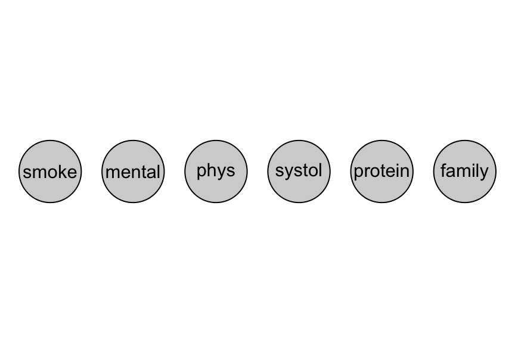

```r
m_init <- dmod(~.^1 , data = reinis)
plot(m_init)
```

```r
m_reinis <- stepwise(m_init, criterion = 'aic', details = T,
                     direction = 'forward', type = 'unrestricted')
```

```
## STEPWISE:
##  criterion: aic ( k = 2 )
##  direction: forward
##  type     : unrestricted
##  search   : all
##  steps    : 1000
## . FORWARD: type=unrestricted search=all, criterion=aic(2.00), alpha=0.00
## . Initial model: is graphical=TRUE is decomposable=TRUE
##   change.AIC -683.9717 Edge added: mental phys
##   change.AIC  -25.4810 Edge added: smoke phys
##   change.AIC  -15.9293 Edge added: protein mental
##   change.AIC  -38.4224 Edge added: smoke protein
##   change.AIC  -23.6185 Edge added: systol protein
##   change.AIC  -29.0833 Edge added: smoke systol
##   change.AIC   -8.7290 Edge added: phys protein
##   change.AIC   -2.7316 Edge added: family mental
```

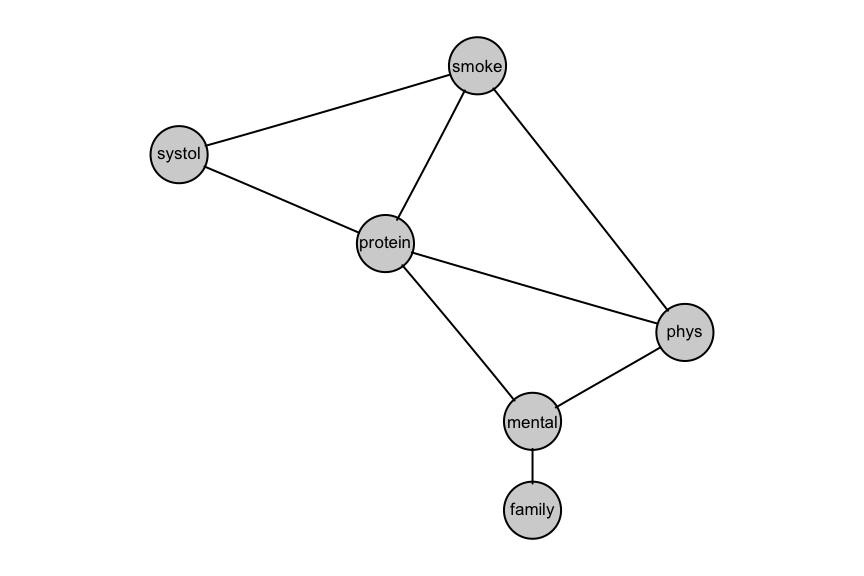

```r
plot(m_reinis)
```

Un ejemplo simple con datos reales: en este caso, queremos entender los patrones de variación de tres variables: color de ojos, color de pelo y género.

```r
data(HairEyeColor)
(HairEyeColor)
```

```
## , , Sex = Male
##
##        Eye
## Hair    Brown Blue Hazel Green
##   Black    32   11    10     3
##   Brown    53   50    25    15
##   Red      10   10     7     7
##   Blond     3   30     5     8
##
## , , Sex = Female
##
##        Eye
## Hair    Brown Blue Hazel Green
##   Black    36    9     5     2
##   Brown    66   34    29    14
##   Red      16    7     7     7
##   Blond     4   64     5     8
```

```r
m_init <- dmod(~.^., data=HairEyeColor)
```

- Primero construye un modelo no dirigido que incluya todos los datos.
- Vimos en una tarea anterior que la única indicación de dependencia entre aceptación y género estaba en un departamento particular (dept A). Construye entonces dos modelos log-lineales: uno para el departamento A y otro para el resto. Explica por qué usar dos modelos es mejor para uno solo para entender estos datos.